# Лекция 15. Медиация: через что работает эффект

Блок 4. Механизмы и гетерогенность

Карен Аванесян

Каузальный анализ в R на данных RLMS-HSE

# Зачем

## Эффект есть. А через что он работает?

- Блоки 1–3 отвечали на вопрос «**сколько**»: диплом добавляет ≈ 0.25 лога к зарплате. Для политики часто важнее «**как**»: диплом даёт доступ к профессиям с высокой оплатой — или повышает зарплату внутри той же профессии?
- Если всё дело в доступе к профессиям, то важна не учёба, а «входной билет» — и тогда сертификация или квоты сработают так же. Если нет — работает содержание обучения
- **Медиация** — разложение полного эффекта на **прямой** и **косвенный** (через медиатор $M$)

Медиация требует допущений сильнее всего, что было до сих пор: даже эксперимент с рандомизацией $D$ не говорит, через что он работает. Поэтому главное на этом занятии — правильно прочитать вывод пакета и провести анализ чувствительности.

## Пример занятия

6 689 человек: занятые 25–60 лет

2016 волна RLMS с «Большой пятёркой»

ISCO 1–3 медиатор: профессиональные и руководящие позиции

дизайн

### $D \to M \to Y$

$D$ — высшее образование; $Y$ — log зарплаты; $M$ — работа на **профессиональной или руководящей позиции** (руководители, специалисты высшего и среднего уровня). Черты личности O, C, E, A, ES — контроли за способности и мотивацию.

вопрос

### Какая доля отдачи — через позицию?

Второй пример: добросовестность ($C$) → годы образования → зарплата — непрерывные воздействие и медиатор.

## План занятия: двойное занятие

часть 1

### Идея и рабочий цикл `mediation`

1. Прямой, косвенный и полный эффект; Baron–Kenny
2. Последовательная игнорируемость
3. Что симулирует `mediate()`: квази-байес и бутстрап
4. Цикл: модель $M$ → модель $Y$ → `mediate` → `summary` → `plot`
5. Как читать вывод; ошибки, кластеры, бутстрап; взаимодействие $D \times M$

часть 2

### Модели, проверки, чувствительность

1. Бинарные медиатор и исход, непрерывное воздействие
2. Эффекты по подгруппам: `covariates`, `test.modmed`
3. `medsens`: $\rho$ и $R^2$, как читать вывод
4. Проверки: выборка, перекрытие, Baron–Kenny, пост-воздейственные конфаундеры
5. Симуляция, шаблон для статьи, ошибки, чек-лист

# Идея

## Три эффекта

Медиатор — тоже потенциальный исход: $M(1)$, $M(0)$. А исход зависит и от $D$, и от $M$: $Y(d, m)$.

полный

### $Y(1, M(1)) - Y(0, M(0))$

То, что мы оценивали весь курс.

прямой · ADE

### $Y(1, M(d)) - Y(0, M(d))$

Меняем диплом, **фиксируя** профессию на том уровне, какой был бы при $d$.

косвенный · ACME

### $Y(d, M(1)) - Y(d, M(0))$

Диплом тот же, меняется только профессия так, как её изменил бы диплом.

Полный = ACME($d$) + ADE($1-d$). $Y(1, M(0))$ — величина, которую **никогда не наблюдаем**: у человека с дипломом профессия «как без диплома». Это и делает медиацию трудной.

## Что делали раньше: Baron–Kenny

Три регрессии: $Y$ на $D$ (полный, $c$); $M$ на $D$ ($a$); $Y$ на $D$ и $M$ ($c'$ и $b$). Косвенный $= a \cdot b = c - c'$.

- При линейности и без взаимодействий это **совпадает** с ACME. Но арифметика не делает оценку причинной: $b$ — эффект профессии на зарплату — требует, чтобы профессия была «как случайна» при данных $D$ и $X$
- А это уже не про диплом. Диплом может быть хоть рандомизирован — люди в профессии и вне её различаются по способностям, амбициям, связям. Пропущенная переменная между $M$ и $Y$ искажает и $b$, и $c'$
- Современная формулировка (Imai, Keele, Yamamoto 2010) — те же регрессии, но явные допущения, взаимодействия, нелинейные модели и анализ чувствительности

## Последовательная игнорируемость

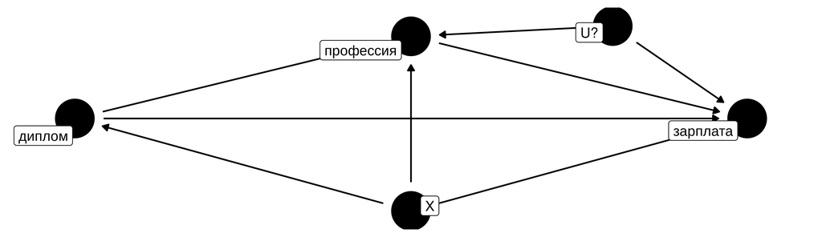

1. При данных $X$ диплом не связан с потенциальными исходами и медиаторами — то же, что в блоке 1
2. При данных $X$ и $D$ профессия не связана с потенциальными исходами: **нет $U$**, и нет переменных, на которые влияет диплом и которые влияют на профессию и зарплату одновременно

## Медиатор и «плохой контроль» — одно и то же

- В лекциях 3–4 мы учили: не контролируйте то, на что влияет воздействие, — оценка полного эффекта сломается
- В медиации мы делаем ровно это, **намеренно**: кондиционируем на $M$, чтобы получить прямой эффект. Вопрос другой — и цена другая: нужно допущение 2
- Отсюда правило чтения чужих работ: «эффект образования с контролем за профессию и отрасль» — это **не** эффект образования и **не** его прямой эффект, пока не обоснована игнорируемость профессии

«Контрольная» переменная, лежащая на пути от $D$ к $Y$, превращает оценку полного эффекта в оценку прямого — со всеми допущениями медиации, о которых авторы обычно не подозревают.

## Что делает `mediate()` внутри

Алгоритм Imai, Keele, Tingley (2010): контрфакт $Y(1, M(0))$ не наблюдается — его **предсказывают** по двум моделям.

**Тянем** `sims` наборов параметров обеих моделей

**Предсказываем** каждому $M(1)$ и $M(0)$ — со случайностью модели $M$

**Предсказываем** $Y(d, M(1))$ и $Y(d, M(0))$ по модели $Y$

**Усредняем** разности → ACME, ADE, полный эффект

**Распределение** по `sims` → оценка, интервал, p-value

- Значит, годится любая пара моделей, из которых можно предсказывать: `lm`, `glm`, `polr`, `rq`, `gam`, `survreg`, `lmer`/`glmer`. Формулы Baron–Kenny не нужны
- Результат — **симуляционный**: от запуска к запуску он слегка меняется. Для отчёта — `set.seed()` и `sims = 1000` (по умолчанию) или больше

## Квази-байес или бутстрап

`boot = FALSE` · по умолчанию

### Квази-байесовская аппроксимация

Параметры тянутся из многомерного нормального с центром в оценках и ковариационной матрицей модели (King, Tomz, Wittenberg 2000). **Быстро.** Матрицу можно заменить: `robustSE = TRUE` (Уайт) или `cluster = d$psu` (кластерная). «Estimate» — среднее по симуляциям.

`boot = TRUE`

### Непараметрический бутстрап

`sims` раз переоцениваем **обе** модели на перевыборке строк. Медленнее, без допущения о нормальности оценок. Интервал: `boot.ci.type = "perc"` (перцентильный, по умолчанию) или `"bca"` (с поправкой на смещение и асимметрию — его рекомендуют для косвенных эффектов). «Estimate» — по исходной выборке.

При `boot = TRUE` аргументы `robustSE` и `cluster` **игнорируются** (с предупреждением). Для части моделей (`gam`, `rq` для медиатора; `polr`, `gam` для исхода) квази-байес невозможен — нужен бутстрап.

# Код

## Рабочий цикл пакета `mediation`

```r
library(mediation)                    # ДО tidyverse / load_panel.R: иначе MASS::select закроет dplyr::select
d <- rlms |> filter(...) |> select(...) |> drop_na() |> as.data.frame()   # 0. одна выборка

model.m <- glm(prof ~ higher_ed + X, data = d, family = binomial("probit"))  # 1. модель медиатора
model.y <- lm(log_wage ~ higher_ed + prof + X, data = d)                     # 2. модель исхода

set.seed(16)
med <- mediate(model.m, model.y, treat = "higher_ed", mediator = "prof",    # 3. симуляции
               sims = 1000)                     # + boot = TRUE / robustSE = TRUE / cluster = d$psu
summary(med); plot(med)                         # 4. таблица и график

sens <- medsens(med, rho.by = 0.05, sims = 50)  # 5. чувствительность к нарушению допущения 2
summary(sens); plot(sens, sens.par = "rho")     # 6. при каком ρ ACME = 0
```

- `treat` и `mediator` — **строки** с именами переменных; `cluster` — **вектор**, а не имя
- Модель медиатора: $M$ на $D$ и $X$. Модель исхода: $Y$ на $D$, $M$ и **те же** $X$

## Требования к моделям

1 · одна выборка

Обе модели на **одних и тех же строках**. Иначе ошибка `number of observations do not match`. `dropobs = TRUE` переоценит на общих строках — лучше `drop_na()` заранее

2 · одно имя $D$

`treat = "higher_ed"` — переменная в обеих моделях под тем же именем. Не `factor(higher_ed)` в одной и `higher_ed` в другой. Медиатор обязан быть в модели исхода

3 · одни и те же $X$

Только **до-воздейственные** ковариаты, обычно одинаковые в обеих моделях. Всё, на что влияет $D$, кроме $M$, — нарушение допущения 2

4 · бинарный $M$

Числовой 0/1, **не factor**. `binomial` — только для 0/1; квазиправдоподобие (`quasibinomial`) не допускается

5 · взаимодействие

`D * M` в модели исхода `mediate` находит сам — и выдаёт эффекты отдельно для $d = 0$ и $d = 1$

6 · не поддерживается

Объекты `feols` и т. п. Фиксированные эффекты — фактором в `lm`/`glm` (у нас `site`). Список классов — в `?mediate`

## Полный эффект и его части руками

0.068 косвенный по Baron–Kenny: $a \cdot b$

0.068 он же: $c - c'$

+47 п.п. диплом → шанс профессиональной позиции

0.14 лога добавляет позиция

- Таблица
- Код

|  | m_tot | m_a | m_cb |
| --- | --- | --- | --- |
| Dependent Var.: | log_wage | prof | log_wage |
| higher_ed | 0.253*** (0.017) | 0.466*** (0.012) | 0.186*** (0.020) |
| prof |  |  | 0.145*** (0.019) |
| _______________ | ________________ | ________________ | ________________ |
| S.E. type | Heterosked.-rob. | Heterosked.-rob. | Heterosked.-rob. |
| Observations | 6,689 | 6,689 | 6,689 |

```r
ctrl <- "female + age + I(age^2) + urban + site + O + C + E + A + ES"
f <- function(lhs, rhs) as.formula(paste(lhs, "~", rhs, "+", ctrl))
m_tot <- feols(f("log_wage", "higher_ed"), d, vcov = "hetero")         # c: полный
m_a   <- feols(f("prof", "higher_ed"), d, vcov = "hetero")             # a: D -> M (LPM)
m_cb  <- feols(f("log_wage", "higher_ed + prof"), d, vcov = "hetero")  # c' и b
etable(m_tot, m_a, m_cb, keep = c("higher_ed", "prof"), depvar = TRUE, fitstat = ~ n)
```

## Базовый вызов на данных RLMS

```r
m_med <- glm(f("prof", "higher_ed"), d, family = binomial("probit"))   # медиатор: пробит
m_out <- lm(f("log_wage", "higher_ed + prof"), d)                       # исход: МНК
set.seed(16)
med <- mediate(m_med, m_out, treat = "higher_ed", mediator = "prof", sims = 1000)
summary(med)
```

6689 = 6689 наблюдений в моделях $M$ и $Y$ — проверить до `mediate`

пробит $M$ бинарный; пробит, а не логит, — ради `medsens`

37 с 1000 квази-байесовских симуляций

## Как читать вывод `summary(mediate)`

- Вывод R
- С пояснениями: строки
- С пояснениями: столбцы

```
Causal Mediation Analysis
Quasi-Bayesian Confidence Intervals
               Estimate 95% CI Lower 95% CI Upper p-value
ACME             0.0664       0.0487       0.0839  <2e-16 ***
ADE              0.1850       0.1463       0.2226  <2e-16 ***
Total Effect     0.2514       0.2174       0.2866  <2e-16 ***
Prop. Mediated   0.2640       0.1882       0.3456  <2e-16 ***
Sample Size Used: 6689
Simulations: 1000
```

1 · ACME

Косвенный эффект: на сколько лог-пунктов вырастает зарплата, если профессия меняется так, как её меняет диплом, а сам диплом нет. У нас 0.066

2 · ADE

Прямой эффект: диплом меняется, профессия зафиксирована. 0.185 — отдача **внутри** позиции

3 · Total Effect

ACME + ADE = 0.251. Сверьте с регрессией без $M$ (0.253): расхождение — сигнал ошибки в моделях

4 · Prop. Mediated

ACME / Total = 26%. Медиана симуляций **отношения**; неустойчива при малом полном эффекте

Одна строка на эффект — потому что исход линейный и без $D \times M$: ACME(0) = ACME(1). Иначе строк станет десять.

5 · шапка

`Quasi-Bayesian Confidence Intervals` или `Nonparametric Bootstrap … Percentile / BCa Method` — как получены интервалы

6 · Estimate и CI

Среднее симуляций и их 2.5% и 97.5% перцентили (уровень — `conf.level`)

7 · p-value

$2 \cdot \min$(доля симуляций > 0, доля < 0). `<2e-16` = ни одной по другую сторону нуля, т. е. $p < 2/$`sims`

8 · Sample Size Used

Число строк в моделях. Должно совпадать с тем, что вы ожидали после `drop_na()`

9 · Simulations

`sims`. При 100 краевые перцентили шумные; для статьи ≥ 1000

сигналы беды

Total ≠ регрессии без $M$; Prop. Mediated < 0 или > 1; ACME и ADE разных знаков; N меньше ожидаемого

## `plot(med)`: тот же результат картинкой

- `plot(med)`
- То же в ggplot
- Код

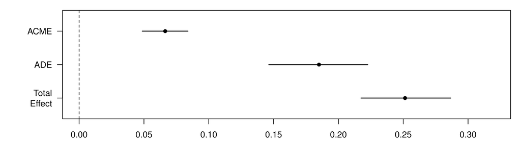

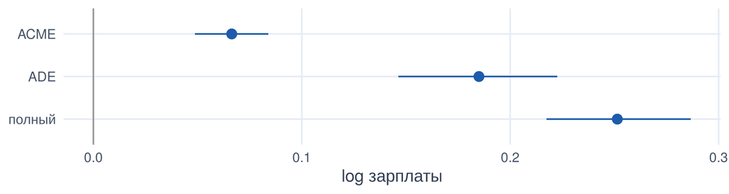

```r
plot(med)                          # точки и 95% интервалы: ACME, ADE, полный
plot(med, treatment = "both")      # при D × M: сплошная — treated, пунктир — control
# свой график: всё лежит в объекте
c(med$d0, med$d0.ci, med$z0, med$tau.coef)   # оценки и интервалы
hist(med$d0.sims)                             # сами симуляции (long = TRUE)
```

- ACME ≈ 0.07: около 26% отдачи от диплома — доступ к профессиональным и руководящим позициям; ADE ≈ 0.19 — остальное внутри позиций
- В объекте `med` есть всё: `d0`, `d1` (ACME), `z0`, `z1` (ADE), `tau.coef`, `n0`, `*.ci`, `*.p` и векторы симуляций `*.sims`

## Ошибки: обычные, robust, кластерные, бутстрап

- Сравнение
- Код

| вариант | ACME | 95% ДИ ACME | полный | 95% ДИ полного |
| --- | --- | --- | --- | --- |
| квази-байес, обычные | 0.066 | [0.049; 0.084] | 0.251 | [0.217; 0.287] |
| квази-байес, robustSE = TRUE | 0.066 | [0.048; 0.084] | 0.251 | [0.217; 0.287] |
| квази-байес, cluster = d$psu | 0.066 | [0.046; 0.087] | 0.252 | [0.210; 0.293] |
| бутстрап 500, perc | 0.067 | [0.050; 0.084] | 0.253 | [0.217; 0.288] |
| бутстрап 500, bca | 0.066 | [0.050; 0.085] | 0.252 | [0.220; 0.281] |

```r
med_rob <- mediate(m_med, m_out, treat = "higher_ed", mediator = "prof", sims = 1000,
                   robustSE = TRUE)                       # sandwich::vcovHC
med_cl  <- mediate(m_med, m_out, treat = "higher_ed", mediator = "prof", sims = 1000,
                   cluster = d$psu)                       # sandwich::vcovCL по ПЕРВИЧНЫМ ЕДИНИЦАМ ОТБОРА
med_bp  <- mediate(m_med, m_out, treat = "higher_ed", mediator = "prof", sims = 500,
                   boot = TRUE)                           # перцентильный
med_bca <- mediate(m_med, m_out, treat = "higher_ed", mediator = "prof", sims = 500,
                   boot = TRUE, boot.ci.type = "bca")     # BCa
```

- RLMS — кластерная выборка по первичным единицам отбора (`psu`): кластерные ошибки — разумный выбор по умолчанию. Здесь они расширяют интервал **полного** эффекта, ACME почти не меняется
- Бутстрап на 500 повторов шёл 69 с против 37 с у 1000 квази-байесовских симуляций. Бутстрап не учитывает кластеры: он перевыбирает строки, а не PSU

## Взаимодействие диплома и профессии

Отдача от позиции может быть разной с дипломом и без. Тогда ACME и ADE зависят от того, при каком $d$ их считать:

```r
m_out2 <- lm(f("log_wage", "higher_ed * prof"), d)      # D × M в модели исхода
med2 <- mediate(m_med, m_out2, treat = "higher_ed", mediator = "prof", sims = 1000)
summary(med2)
test.TMint(med2)                                       # ACME(1) − ACME(0) = 0?
```

control · $d = 0$

**ACME (control)** = $E[Y(0, M(1)) - Y(0, M(0))]$: позиция меняется, отдача от неё — как у людей **без** диплома

treated · $d = 1$

**ACME (treated)** = $E[Y(1, M(1)) - Y(1, M(0))]$: отдача от позиции — как у людей **с** дипломом

пары

Полный = ACME (treated) + ADE (control) = ACME (control) + ADE (treated)

## Как читать вывод `summary(mediate)` с взаимодействием

- Вывод R
- С пояснениями

```
Causal Mediation Analysis
Quasi-Bayesian Confidence Intervals
                         Estimate 95% CI Lower 95% CI Upper p-value
ACME (control)             0.0559       0.0350       0.0787  <2e-16 ***
ACME (treated)             0.0838       0.0561       0.1138  <2e-16 ***
ADE (control)              0.1673       0.1229       0.2123  <2e-16 ***
ADE (treated)              0.1952       0.1541       0.2335  <2e-16 ***
Total Effect               0.2511       0.2172       0.2845  <2e-16 ***
Prop. Mediated (control)   0.2216       0.1352       0.3187  <2e-16 ***
Prop. Mediated (treated)   0.3321       0.2184       0.4623  <2e-16 ***
ACME (average)             0.0699       0.0514       0.0886  <2e-16 ***
ADE (average)              0.1813       0.1435       0.2213  <2e-16 ***
Prop. Mediated (average)   0.2769       0.1945       0.3682  <2e-16 ***
Sample Size Used: 6689
Simulations: 1000
```

1 · ACME (control / treated)

0.056 и 0.084: позиция приносит больше тем, у кого есть диплом

2 · ADE (control / treated)

0.167 и 0.195: прямой эффект при профессии «как без диплома» и «как с дипломом»

3 · Total Effect

Один: 0.251. Проверка: 0.084 + 0.167 ≈ 0.251

4 · Prop. Mediated

22% и 33% — доля зависит от точки отсчёта

5 · (average)

Простое среднее control и treated: ACME 0.070. Удобно, но скрывает различие

когда 10 строк

Есть $D \times M$ **или** исход нелинейный (`glm`) — даже без взаимодействия

## `test.TMint()`: различаются ли ACME(1) и ACME(0)?

- Вывод R
- Как читать

```
    Test of ACME(1) - ACME(0) = 0

data:  estimates from med2
ACME(1) - ACME(0) = 0.03, p-value = 0.1
alternative hypothesis: true ACME(1) - ACME(0) is not equal to 0
95 percent confidence interval:
 -0.00436  0.06026
```

- `ACME(1) - ACME(0)` = 0.028 — разность косвенных эффектов при $d = 1$ и $d = 0$; интервал и p-value — по тем же симуляциям, что и в `mediate`
- p = 0.10, 95% ДИ [-0.004; 0.060]: **различие не значимо**. Тест работает только если в модели исхода есть $D \times M$ (иначе ошибка)
- Вывод: точечно позиция приносит больше обладателям диплома, но данные не позволяют отличить это от нуля. Сообщаем модель с взаимодействием и обе строки — или модель без него с оговоркой, что тест не отверг равенство
- Если взаимодействие значимо, сообщайте обе ACME: строка `(average)` скрывает именно то, что интересно

## Какие модели понимает `mediate()`

`mediate` · таблица 1 виньетки

### Медиатор и исход

| Медиатор ↓ / исход → | lm, glm | polr | rq, survreg, tobit |
| --- | --- | --- | --- |
| `lm`, `glm`, `polr` | ✓ | ✓ boot | ✓ |
| `rq`, `gam` | ✓ boot | ✓ boot | ✓ boot |
| tobit (`vglm`) | — | — | — |

`glmer`/`lmer` — многоуровневые; `gam`-исход — только бутстрап

`medsens` · таблица 2

### Чувствительность — только три пары

| Медиатор | Исход | type |
| --- | --- | --- |
| `lm` | `lm` | ct |
| `glm` probit | `lm` | bm |
| `lm` | `glm` probit | bo |

Пробит-исход — без $D \times M$. Логит, probit–probit, `polr` → ошибка

Выбор модели — не только про данные, но и про то, сможете ли вы потом проверить чувствительность.

## Бинарный медиатор: пробит, логит или LPM

- Сравнение
- `medsens` для логита

| модель M | ACME | 95% ДИ | ADE | доля |
| --- | --- | --- | --- | --- |
| glm probit | 0.066 | [0.049; 0.084] | 0.185 | 26% |
| glm logit | 0.066 | [0.049; 0.084] | 0.185 | 26% |
| lm (LPM) | 0.067 | [0.049; 0.084] | 0.186 | 27% |

```r
m_logit   <- glm(f("prof", "higher_ed"), d, family = binomial("logit"))
med_logit <- mediate(m_logit, m_out, treat = "higher_ed", mediator = "prof", sims = 1000)
medsens(med_logit, rho.by = 0.1)
```

```
Error: medsens is only valid for the probit link
```

- Три модели медиатора — практически одна оценка: при хорошем перекрытии форма связи $D \to M$ мало что меняет
- Но `medsens` выводится из **нормальных** латентных ошибок: формулы есть для пробита, а для логита нет. Поэтому для бинарного медиатора берём пробит

## Бинарный исход: диплом → позиция → официальное оформление

```r
d_o     <- d |> filter(!is.na(official))           # у official есть пропуски: обе модели на d_o
m_med_o <- glm(f("prof", "higher_ed"), d_o, family = binomial("probit"))
m_off   <- glm(f("official", "higher_ed + prof"), d_o, family = binomial("probit"))
med_bb  <- mediate(m_med_o, m_off, treat = "higher_ed", mediator = "prof", sims = 1000)
```

- Вывод R
- Как читать

```
                         Estimate 95% CI Lower 95% CI Upper p-value
ACME (control)            0.03587      0.02945      0.04274  <2e-16 ***
ACME (treated)            0.02713      0.01946      0.03561  <2e-16 ***
ADE (control)             0.02476      0.00672      0.04084   0.006 **
ADE (treated)             0.01603      0.00406      0.02701   0.006 **
Total Effect              0.05189      0.03962      0.06441  <2e-16 ***
Prop. Mediated (control)  0.68917      0.54788      0.90204  <2e-16 ***
Prop. Mediated (treated)  0.51455      0.33563      0.83713  <2e-16 ***
ACME (average)            0.03150      0.02496      0.03858  <2e-16 ***
ADE (average)             0.02039      0.00541      0.03372   0.006 **
Prop. Mediated (average)  0.60186      0.44388      0.87096  <2e-16 ***
```

- Эффекты — в **вероятности**: диплом повышает шанс официального оформления на 5 п.п., из них 3.1 п.п. (в среднем) — через позицию
- 10 строк без всякого $D \times M$: в пробите эффект позиции зависит от уровня остальных слагаемых, поэтому ACME(0) ≠ ACME(1)
- `medsens(med_bb)` → ошибка «mediate object fitted with non-supported model combinations»: пара probit–probit не поддерживается

## Линейный медиатор, бинарный исход

Добросовестность ($C$, +1 SD) → годы образования → профессиональная позиция. Пара lm–probit: `medsens` работает.

- Вывод R
- Код

```
                          Estimate 95% CI Lower 95% CI Upper p-value
ACME (control)            0.010466     0.004569     0.016902  <2e-16 ***
ACME (treated)            0.010482     0.004560     0.016901  <2e-16 ***
ADE (control)             0.003265    -0.008287     0.015242   0.592
ADE (treated)             0.003281    -0.008330     0.015307   0.592
Total Effect              0.013747     0.000112     0.027385   0.046 *
Prop. Mediated (control)  0.746152     0.161017     4.091615   0.046 *
Prop. Mediated (treated)  0.747222     0.162192     4.082372   0.046 *
ACME (average)            0.010474     0.004565     0.016911  <2e-16 ***
ADE (average)             0.003273    -0.008308     0.015275   0.592
Prop. Mediated (average)  0.746687     0.161605     4.086993   0.046 *
```

```r
ctrl2 <- "O + E + A + ES + female + age + I(age^2) + urban + site"
mm    <- lm(as.formula(paste("years_educ ~ C +", ctrl2)), d)
mo_p  <- glm(as.formula(paste("prof ~ C + years_educ +", ctrl2)), d,
             family = binomial("probit"))
med_lb  <- mediate(mm, mo_p, treat = "C", mediator = "years_educ",
                   control.value = 0, treat.value = 1, sims = 1000)
sens_lb <- medsens(med_lb, rho.by = 0.1, sims = 50)    # тип "bo": работает
```

ACME = 0.0105 уверенно отличен от нуля, полный эффект — на грани (p = 0.046, нижняя граница 0.0001). Посмотрите на интервал `Prop. Mediated`.

## Prop. Mediated: когда доле нельзя верить

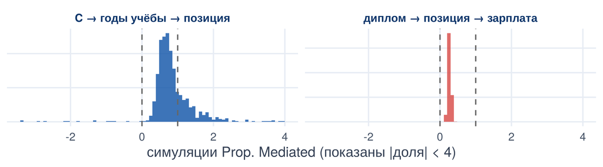

- Доля — **отношение** двух шумных чисел. Когда полный эффект едва отличим от нуля, знаменатель в части симуляций около нуля или другого знака — и доля улетает: интервал [0.2; 4.1] против [0.19; 0.35] в основном примере
- Правило: сообщать долю, только если полный эффект явно отличен от нуля, а ACME и ADE одного знака. Иначе — ACME и ADE в единицах исхода

## Непрерывное воздействие: `treat.value` и `control.value`

- Код
- Вывод R: 0 → 1
- Вывод R: −1 → 1

```r
# добросовестность (C, z-score) -> годы образования -> зарплата
mm <- lm(years_educ ~ C + O + E + A + ES + female + age + I(age^2) + urban + site, d)
mo <- lm(log_wage ~ C + years_educ + O + E + A + ES + female + age + I(age^2) + urban + site, d)
medC  <- mediate(mm, mo, treat = "C", mediator = "years_educ", sims = 1000,
                 control.value = 0, treat.value = 1)      # эффект +1 SD добросовестности
medC2 <- mediate(mm, mo, treat = "C", mediator = "years_educ", sims = 1000,
                 control.value = -1, treat.value = 1)     # от −1 SD до +1 SD
```

```
Causal Mediation Analysis
Quasi-Bayesian Confidence Intervals
               Estimate 95% CI Lower 95% CI Upper p-value
ACME            0.00557      0.00212      0.00909  <2e-16 ***
ADE             0.03928      0.01934      0.05904  <2e-16 ***
Total Effect    0.04485      0.02454      0.06419  <2e-16 ***
Prop. Mediated  0.12487      0.04671      0.25450  <2e-16 ***
Sample Size Used: 6689
Simulations: 1000
```

```
Causal Mediation Analysis
Quasi-Bayesian Confidence Intervals
               Estimate 95% CI Lower 95% CI Upper p-value
ACME            0.01141      0.00497      0.01865  <2e-16 ***
ADE             0.07830      0.03810      0.11573  <2e-16 ***
Total Effect    0.08971      0.04944      0.12869  <2e-16 ***
Prop. Mediated  0.12690      0.05370      0.24677  <2e-16 ***
Sample Size Used: 6689
Simulations: 1000
```

- Для непрерывного $D$ эффект определяется **парой** значений; по умолчанию `control.value = 0`, `treat.value = 1` — для z-score это +1 SD от среднего
- В линейных моделях результат пропорционален разности: от −1 до +1 SD ACME = 0.0114 ≈ 2 × 0.0056. В нелинейных пара значений меняет ответ — выбирайте осмысленную (квартили, ±1 SD)

## Что видно

- +1 SD добросовестности: +4.5% зарплаты, из них 12% через лишние годы учёбы. Личность работает в основном напрямую — на рабочем месте
- Чувствительность (lm–lm): ACME обращается в ноль при $\rho$ = 0.20 — ненаблюдаемая общая причина образования и зарплаты (способности, семья) такой силы вполне правдоподобна
- Оговорка: черты измерены в 2016, образование получено раньше. Мы допускаем, что личность стабильна; если учёба меняет добросовестность — стрелка обратная, и расчёт теряет смысл

## Эффекты для подгрупп: `covariates =`

```r
m_med_f <- glm(f("prof", "higher_ed * female"), d, family = binomial("probit"))   # D × пол
m_out_f <- lm(f("log_wage", "higher_ed * female + prof * female"), d)             # D × пол, M × пол
med_w <- mediate(m_med_f, m_out_f, treat = "higher_ed", mediator = "prof",
                 covariates = list(female = 1), sims = 1000)                       # женщины
med_m <- mediate(m_med_f, m_out_f, treat = "higher_ed", mediator = "prof",
                 covariates = list(female = 0), sims = 1000)                       # мужчины
```

0.072 ACME, женщины · доля 27%

0.061 ACME, мужчины · доля 27%

0.269 полный эффект, женщины

0.230 полный эффект, мужчины

- В шапке вывода появляется строка `(Inference Conditional on the Covariate Values Specified in 'covariates')`: эффекты посчитаны при `female = 1`, остальные $X$ усреднены по выборке
- Модератор должен **взаимодействовать** с $D$ и $M$ в моделях — иначе (в линейных моделях) эффекты у подгрупп совпадут по построению

## `test.modmed()`: значима ли разница между подгруппами?

- Вывод R
- Код

```
    Test of ACME(covariates.1) - ACME(covariates.2) = 0
data:  estimates from med_init
ACME(covariates.1) - ACME(covariates.2) = 0.01, p-value = 0.5
95 percent confidence interval:
 -0.0238  0.0452
    Test of ADE(covariates.1) - ADE(covariates.2) = 0
data:  estimates from med_init
ADE(covariates.1) - ADE(covariates.2) = 0.03, p-value = 0.4
95 percent confidence interval:
 -0.0399  0.1023
```

```r
med_init <- mediate(m_med_f, m_out_f, treat = "higher_ed", mediator = "prof",
                    sims = 2)                        # сам вызов — лишь «заготовка»
test.modmed(med_init, covariates.1 = list(female = 1),
                      covariates.2 = list(female = 0), sims = 500)
```

- Два теста: `ACME(covariates.1) - ACME(covariates.2)` = 0.011, p = 0.53; то же для ADE: 0.030, p = 0.45
- Различия между женщинами и мужчинами **не значимы**: «у женщин механизм другой» на этих данных не подтверждается. `test.modmed` сам перезапускает `mediate` дважды — `sims` в заготовке не важны

## Чувствительность: что если есть $U$?

Пусть ошибки уравнений медиатора и исхода коррелируют с $\rho$ — это и есть след ненаблюдаемого $U$. `medsens` пересчитывает ACME для каждого $\rho$:

```r
sens <- medsens(med, rho.by = 0.05, sims = 50,     # шаг по ρ; sims — для интервалов (bm, bo)
                effect.type = "indirect")          # "direct" или "both" — для ADE
summary(sens)
plot(sens, sens.par = "rho")                       # ACME(ρ)
plot(sens, sens.par = "R2", r.type = "total", sign.prod = "positive")
```

$\rho > 0$

$U$ двигает $M$ и $Y$ в **одну** сторону (способности → и позиция, и зарплата). ACME завышена

$\rho < 0$

$U$ двигает их в **разные** стороны. ACME занижена

время

Пробит–lm: `rho.by` × `sims` перезапусков. Ставьте шаг 0.05–0.1 и `sims` 50–100

## Как читать вывод `summary(medsens)`

- Вывод R
- С пояснениями

```
Mediation Sensitivity Analysis for Average Causal Mediation Effect
Sensitivity Region
      Rho    ACME 95% CI Lower 95% CI Upper R^2_M*R^2_Y* R^2_M~R^2_Y~
[1,] 0.15 -0.0079      -0.0247       0.0054       0.0225       0.0092
Rho at which ACME = 0: 0.15
R^2_M*R^2_Y* at which ACME = 0: 0.0225
R^2_M~R^2_Y~ at which ACME = 0: 0.0092
```

1 · Sensitivity Region

Строки таблицы — значения $\rho$, при которых 95% интервал ACME **накрывает ноль**. Чем ближе они к $\rho = 0$, тем хрупче результат

2 · Rho at which ACME = 0

0.15: такая корреляция ошибок уравнений $M$ и $Y$ обнуляет косвенный эффект

3 · `R^2_M*R^2_Y*`

0.023: произведение долей **остаточной** дисперсии $M$ и $Y$, которые объяснил бы $U$

4 · `R^2_M~R^2_Y~`

0.009: то же для **общей** дисперсии. Его легче сравнивать с $R^2$ наблюдаемых $X$

5 · с взаимодействием

Для модели с $D \times M$ — отдельные блоки и пороги для ACME (control) и ACME (treated)

сигналы беды

ACME = 0 при малом $|\rho|$; произведение $R^2$ меньше, чем у наблюдаемых контролей. Для бинарного $M$ $R^2$ — латентной переменной

## Насколько хрупок косвенный эффект

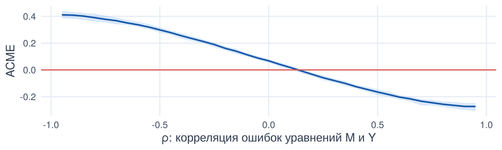

- ACME обращается в ноль уже при $\rho \approx$ 0.15: $U$, объясняющий около 15% остаточной дисперсии в каждом из уравнений, стирает косвенный эффект. Это тот же график, что `plot(sens, sens.par = "rho")`
- Такой $U$ правдоподобен: способности, связи, амбиции влияют и на позицию, и на зарплату

## Чувствительность в терминах $R^2$

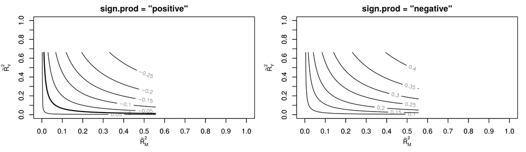

- Оси — доли **общей** дисперсии $M$ и $Y$, объяснённые $U$ (`r.type = "total"`; `"residual"` — остаточной); линии — уровни ACME, **жирная** — ACME = 0; левый нижний угол — $U$ нет
- `sign.prod = "positive"`: $U$ повышает и позицию, и зарплату — ACME падает до нуля; `"negative"`: в разные стороны — ACME только растёт

## Ориентир: насколько силён должен быть $U$

Сравним порог из `medsens` с тем, сколько дисперсии объясняют **наблюдаемые** конфаундеры — вся «Большая пятёрка» сразу (прирост $R^2$ при её добавлении, LPM для позиции).

0.0092 порог $\tilde R^2_M \tilde R^2_Y$, при котором ACME = 0

1.5% дисперсии позиции объясняют O, C, E, A, ES

1.2% дисперсии зарплаты объясняют O, C, E, A, ES

0.00018 их произведение — в 50 раз меньше порога

- Чтобы обнулить ACME, $U$ должен быть намного сильнее всех пяти черт личности вместе. Но черты — слабый ориентир: способности, качество вуза, связи объясняют зарплату гораздо лучше
- Калибровка грубая ($R^2$ LPM, а не латентной переменной пробита). Её смысл — перевести $\rho$ в язык «насколько сильнее того, что мы уже контролируем»

## Проверка 1: одна и та же выборка

- Ошибка
- Код

```
nobs(m_med) = 6689   nobs(m_bad) = 6047
```

```
Error: number of observations do not match between mediator and outcome models
```

```r
m_bad <- lm(f("log_wage", "higher_ed + prof + official"), d)   # official с пропусками
c(nobs(m_med), nobs(m_bad))                                    # проверять ДО mediate
mediate(m_med, m_bad, treat = "higher_ed", mediator = "prof")  # ошибка
mediate(m_med, m_bad, ..., dropobs = TRUE)  # переоценит обе модели на общих строках
# лучше: d_o <- d |> filter(!is.na(official)) и обе модели на d_o
```

- `lm` и `glm` молча выбрасывают строки с пропусками. Если пропуски в разных переменных — модели оценены на разных людях, а контрфакт $Y(1, M(0))$ склеивается из несопоставимых частей
- `dropobs = TRUE` спасает вызов, но меняет выборку: сравните `med$nobs` с ожидаемым N и сообщите, сколько строк ушло

## Проверка 2: перекрытие по медиатору

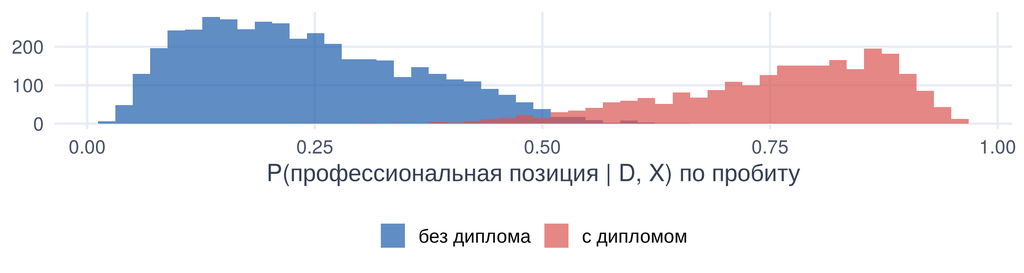

- Допущение 2 требует ещё и $0 < P(M = m \mid D, X) < 1$: должны быть люди без диплома на профессиональных позициях и с дипломом — вне их. В таблице $D \times M$ самая малая клетка — 571 человек
- Прогнозы пробита не прижаты к 0 и 1: у людей без диплома максимум 0.65, у людей с дипломом минимум 0.23. Где перекрытия нет, $Y(0, M(1))$ — экстраполяция модели

## Проверка 3: сверка с Baron–Kenny

| способ | ACME | 95% ДИ | полный |
| --- | --- | --- | --- |
| Baron–Kenny: a · b (feols) | 0.068 | — | 0.253 |
| mediate: lm – lm (LPM) | 0.067 | [0.049; 0.084] | 0.253 |
| mediate: probit – lm | 0.066 | [0.049; 0.084] | 0.251 |
| mediate: logit – lm | 0.066 | [0.049; 0.084] | 0.251 |

- lm–lm воспроизводит $a \cdot b$ с точностью до шума симуляций — так и должно быть (`?mediate`: «identical to the usual LSEM method»). Если не совпадает — модели оценены на разных данных или с разными $X$
- Сильное расхождение пробита и LPM — сигнал плохого перекрытия или неверной формы: смотрите проверку 2

## Проверка 4: пост-воздейственный конфаундер

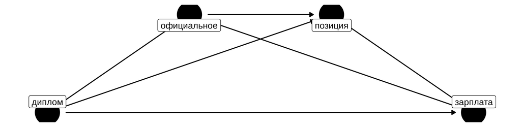

- $L$ зависит от диплома и влияет на позицию и зарплату. **Не включить** $L$ — нарушить допущение 2 (общая причина $M$ и $Y$). **Включить** как ковариату — кондиционировать на следствии $D$: ACME перестаёт быть косвенным эффектом. `mediate` корректно не умеет ни то, ни другое
- Что делать: (1) считать $(L, M)$ **одним** механизмом; (2) `multimed()` (Imai, Yamamoto 2013) — ACME при допущении однородного взаимодействия и анализ чувствительности к нему; (3) контролируемый прямой эффект — sequential g-estimation (пакет `DirectEffects`)

## Проверка 4 на данных: `multimed()`

- Сравнение
- Вывод R
- Код

| спецификация | ACME | ADE | полный |
| --- | --- | --- | --- |
| mediate: L не учтён | 0.072 | 0.187 | 0.259 |
| mediate: L как ковариата | 0.067 | 0.186 | 0.252 |
| multimed: L = med.alt | 0.070 | 0.184 | 0.260 |

```
Estimates under the Homogeneous Interaction Assumption:
               Estimate 95% CI Lower 95% CI Upper
ACME (treated)   0.0855       0.0541       0.1170
ACME (control)   0.0609       0.0373       0.0844
ACME (average)   0.0702       0.0510       0.0893
ADE (treated)    0.1993       0.1551       0.2436
ADE (control)    0.1746       0.1288       0.2204
ADE (average)    0.1839       0.1428       0.2251
Total Effect     0.2602       0.2250       0.2983
```

```r
dm <- d_o |> mutate(age2 = age^2)            # multimed: имена столбцов, а не формула
mmed <- multimed(outcome = "log_wage", med.main = "prof",
                 med.alt = "official",        # пост-воздейственный конфаундер L
                 treat = "higher_ed", data = dm, sims = 500,   # sims — бутстрап
                 covariates = c("female", "age", "age2", "urban", "site", "O", "C", "E", "A", "ES"))
summary(mmed); plot(mmed)
```

- Все три оценки близки: официальное оформление — слабый конфаундер позиции и зарплаты. Если бы ACME сильно менялся, механизмы «через позицию» и «через формальный сектор» было бы не разделить
- `multimed`: линейные модели и **однородное** взаимодействие $D \times M$; ACME (average) теряет значимость, если его неоднородность объясняет 1.4% общей дисперсии $Y$ (`R2t(CI)`)

## Симуляция: эксперимент не спасает

- Результат
- Код

| эффект | истина | оценка |
| --- | --- | --- |
| ACME | 0.2 | 0.435 |
| ADE | 0.3 | 0.046 |
| полный | 0.5 | 0.481 |

```r
set.seed(1); n <- 5000; U <- rnorm(n); D <- rbinom(n, 1, 0.5)  # D случаен, U скрыт
M <- 0.5 * D + 0.8 * U + rnorm(n)                               # ACME = 0.5 * 0.4 = 0.2
Y <- 0.3 * D + 0.4 * M + 0.8 * U + rnorm(n)                     # ADE = 0.3, полный = 0.5
s <- data.frame(D, M, Y)
naive <- mediate(lm(M ~ D, s), lm(Y ~ D + M, s), treat = "D", mediator = "M", sims = 200)
tibble(эффект = c("ACME", "ADE", "полный"), истина = c(0.2, 0.3, 0.5),
       оценка = round(c(naive$d0, naive$z0, naive$tau.coef), 3))
```

- Полный эффект верен: $D$ рандомизирован. Но ACME в 2.2 раза больше истины, а прямой почти исчез: $U$ завышает $b$, и прямой эффект «переезжает» в косвенный
- Рандомизация $D$ закрывает допущение 1, но не 2. Для 2 нужно рандомизировать и медиатор или найти для него инструмент

## Как писать результат

шаблон

«Высшее образование повышает log зарплаты на **0.251** (95% ДИ [0.210; 0.293], кластеры по PSU). Около **26%** этого эффекта — ACME = 0.066 ([0.046; 0.087]) — приходится на доступ к профессиональным и руководящим позициям; прямой эффект внутри позиций — 0.185. Оценки — `mediate` (Imai et al. 2010; пробит для позиции, МНК для зарплаты; пол, возраст, тип поселения, регион и Big Five; 1000 квази-байесовских симуляций). Разложение держится на **последовательной игнорируемости**: при данных контролях нет общих причин позиции и зарплаты. Косвенный эффект обращается в ноль при $\rho$ = 0.15, т. е. если ненаблюдаемый фактор объясняет по ≈ 10% общей дисперсии позиции и зарплаты ($\tilde R^2_M \tilde R^2_Y$ = 0.0092).»

- Обязательно: estimand (ACME / ADE, при каком $d$, если есть $D \times M$), модели, тип интервалов и `sims`, $\rho$ и $R^2$ при ACME = 0, оговорка о допущении 2
- Не писать: «механизм доказан», «26% эффекта объясняется профессией» без оговорки; долю — при незначимом полном эффекте

# Как ошибаются

## Восемь ошибок с медиацией

ошибка 1

### Медиатор «для чистоты»

Контроль за профессию при оценке полного эффекта

**Как правильно:** это уже прямой эффект — со всеми допущениями медиации (лекции 3–4)

ошибка 2

### $a \cdot b$ без допущений

Произведение коэффициентов как «косвенный эффект»

**Как правильно:** назвать допущение 2 и показать `medsens`; без этого число не причинное

ошибка 3

### Медиатор не после $D$

Профессия измерена до диплома или одновременно

**Как правильно:** проверить порядок $D \to M \to Y$ во времени; иначе стрелка может быть обратной

ошибка 4

### Пост-воздейственный $L$

$L$ «просто добавили» в обе модели

**Как правильно:** $(L, M)$ как один механизм, `multimed` или контролируемый прямой эффект

## Восемь ошибок с медиацией (2)

ошибка 5

### Разные выборки

`dropobs = TRUE` «чтобы заработало»

**Как правильно:** `drop_na()` до моделей, сверить `nobs()` и `Sample Size Used`

ошибка 6

### Доля при нулевом эффекте

«Медиатор объясняет 75%»

**Как правильно:** долю — только при явном полном эффекте и одинаковых знаках ACME и ADE

ошибка 7

### Логит — и без чувствительности

`medsens` выдал ошибку, анализ пропущен

**Как правильно:** пробит или lm для $M$; `medsens` работает только в трёх парах моделей

ошибка 8

### Ошибки без дизайна

Квази-байес с обычной матрицей, `sims = 100`

**Как правильно:** `cluster = d$psu` или BCa-бутстрап, `sims` ≥ 1000, `set.seed()`

## Чек-лист

- Вопрос сформулирован: полный, прямой или косвенный эффект; при каком $d$
- DAG: $D \to M \to Y$, $X$, возможный $U$ и пост-воздейственные $L$; порядок во времени соблюдён
- Одна таблица после `drop_na()`; `nobs()` моделей совпадают, `Sample Size Used` — ожидаемый
- Модели: пробит или lm для $M$ (ради `medsens`); одинаковые до-воздейственные $X$; `test.TMint`, `test.modmed`
- `mediate`: `set.seed()`, `sims` ≥ 1000; `cluster` или бутстрап (`bca`); перекрытие и сверка с $a \cdot b$
- `medsens`: $\rho$ и $\tilde R^2_M \tilde R^2_Y$ при ACME = 0, сравнение с наблюдаемыми $X$
- Prop. Mediated — только при явном полном эффекте; в тексте — оговорка о допущении 2

# Мини-задача

## Задание к следующему занятию

1. Разложите эффект диплома на зарплату через **официальное оформление** (`official`) вместо профессии. Какая доля идёт через формальный сектор? Нарисуйте DAG, назовите наиболее вероятный $U$ и проведите `medsens` (какая пара моделей для этого нужна?)
2. Повторите основной анализ отдельно для женщин и мужчин через `covariates` и `test.modmed`, добавив взаимодействие с `urban`. Где различия значимы?
3. Для разложения через профессию добавьте в модель исхода `hours_week`. Что это за переменная относительно $M$ и $Y$ — контроль, медиатор или коллайдер? Как меняются ACME и ADE и имеет ли это смысл?
4. Повторите симуляцию с $U$, влияющим только на $M$ (не на $Y$). Что происходит с ACME? Сравните с выводом `medsens` для этих данных

# Литература

## Что прочитать

- Imai K., Keele L., Tingley D. (2010). A General Approach to Causal Mediation Analysis. *Psychological Methods* — алгоритм `mediate`, с кодом
- Imai K., Keele L., Yamamoto T. (2010). Identification, Inference and Sensitivity Analysis for Causal Mediation Effects. *Statistical Science* — допущения, $\rho$ и $R^2$
- Imai K., Keele L., Tingley D., Yamamoto T. (2011). Unpacking the Black Box of Causality: Learning about Causal Mechanisms from Experimental and Observational Studies. *American Political Science Review* — дизайны и как писать о механизмах
- Tingley D., Yamamoto T., Hirose K., Keele L., Imai K. (2014). mediation: R Package for Causal Mediation Analysis. *Journal of Statistical Software* 59(5) — виньетка пакета: `vignette("mediation")`
- Imai K., Yamamoto T. (2013). Identification and Sensitivity Analysis for Multiple Causal Mechanisms. *Political Analysis* — `multimed`
- Acharya A., Blackwell M., Sen M. (2016). Explaining Causal Findings Without Bias: Detecting and Assessing Direct Effects. *APSR* — контролируемые прямые эффекты, `DirectEffects`
- VanderWeele T. (2015). *Explanation in Causal Inference: Methods for Mediation and Interaction*. Oxford University Press — учебник по медиации и взаимодействию

Каузальный анализ в R · RLMS-HSE · К. Аванесян

← К программе курса